# *Project#2 Univariate and Bivariate Analysis*

Aesha Rathod || Gurjinderpal Singh || Tehsin Shaikh

# **0. Project Overview**

Project#2 is all about cleaning and analyzing the data, including identifying and handling outliers, describing the shape of the data, and selecting appropriate measures of central tendency and spread. The goal of the analysis is to gain a better understanding of the distribution and characteristics of the data, and to make informed decisions about how to analyze and interpret it. To summarize, this task requires a combination of data cleaning, data visualization, and statistical analysis skills, and is designed to help the students develop a more complete and accurate understanding of the data.

Univariate analysis typically involves computing summary statistics, such as mean, median, mode, variance, standard deviation, and other measures of central tendency and variability. It may also involve creating visualizations of the data, such as histograms, box plots, and density plots, to gain insight into the distribution of the variable.

Bivariate analysis in R involves exploring the relationship between two variables. This can be done by computing the correlation coefficient between the two variables, creating a scatter plot to visualize the relationship, and fitting a regression model to the data. In addition, there are many packages in R, such as ggplot2 and lattice, that provide tools for creating more advanced visualizations of bivariate data.

# **1. Analysis by Tehsin Shaikh**

```r
#Import the necessary libraries and packages
library(tidyverse)
```

```r
library(readxl)
library(ggplot2)
library(dplyr)
library(stringr)
```

```r
# Load the dataset
library(readxl)
smd <- read_excel("C:/Users/MY PC/Desktop/DAB_Project2/Datasets/smd.xlsx")
```

```r
#change column names to make it easy to understand for R
colnames(smd) <-c("Order_Id","Company_Id","Company_Name","Date_ order_placed","DD_Order_Placed_Date","MM _Order_Placed_Month","YYYY_Order_Placed_Year","Order_Value","Converted","Date","Meal_Id","Date_of_Meal","YYYY_Meal_Served_Year","MM_Meal_Served_Month","DD_Meal_Served_Date","Participant","Meal_Price","Type_of_Meal","Sales_Rep","Sales_Rep_Id")
print(colnames(smd))
```

```
##  [1] "Order_Id"               "Company_Id"             "Company_Name"
##  [4] "Date_ order_placed"     "DD_Order_Placed_Date"   "MM _Order_Placed_Month"
##  [7] "YYYY_Order_Placed_Year" "Order_Value"            "Converted"
## [10] "Date"                   "Meal_Id"                "Date_of_Meal"
## [13] "YYYY_Meal_Served_Year"  "MM_Meal_Served_Month"   "DD_Meal_Served_Date"
## [16] "Participant"            "Meal_Price"             "Type_of_Meal"
## [19] "Sales_Rep"              "Sales_Rep_Id"
```

```r
# check for missing values in the entire data frame
sum(is.na(smd))
```

```
## [1] 449847
```

```r
# check for missing values in each column of the data frame
colSums(is.na(smd))
```

```
##               Order_Id             Company_Id           Company_Name
##                      0                      0                      0
##     Date_ order_placed   DD_Order_Placed_Date MM _Order_Placed_Month
##                      0                      0                      0
## YYYY_Order_Placed_Year            Order_Value              Converted
##                      0                      0                      0
##                   Date                Meal_Id           Date_of_Meal
##                  49983                  49983                  49983
##  YYYY_Meal_Served_Year   MM_Meal_Served_Month    DD_Meal_Served_Date
##                  49983                  49983                  49983
##            Participant             Meal_Price           Type_of_Meal
##                  49983                  49983                  49983
##              Sales_Rep           Sales_Rep_Id
##                      0                      0
```

```r
#Remove missing values from the data frame
smd <-na.omit(smd)
```

```r
#check for missing values in each column of the data frame after clean up
colSums(is.na(smd))
```

```
##               Order_Id             Company_Id           Company_Name
##                      0                      0                      0
##     Date_ order_placed   DD_Order_Placed_Date MM _Order_Placed_Month
##                      0                      0                      0
## YYYY_Order_Placed_Year            Order_Value              Converted
##                      0                      0                      0
##                   Date                Meal_Id           Date_of_Meal
##                      0                      0                      0
##  YYYY_Meal_Served_Year   MM_Meal_Served_Month    DD_Meal_Served_Date
##                      0                      0                      0
##            Participant             Meal_Price           Type_of_Meal
##                      0                      0                      0
##              Sales_Rep           Sales_Rep_Id
##                      0                      0
```

## **Univariate Analysis**

### A) For each numeric variable:

*1. Clean the data for any outlier/extreme values using the filtering technique and create an appropriate plot to visualize the distribution of numeric variable “Order Value”.*

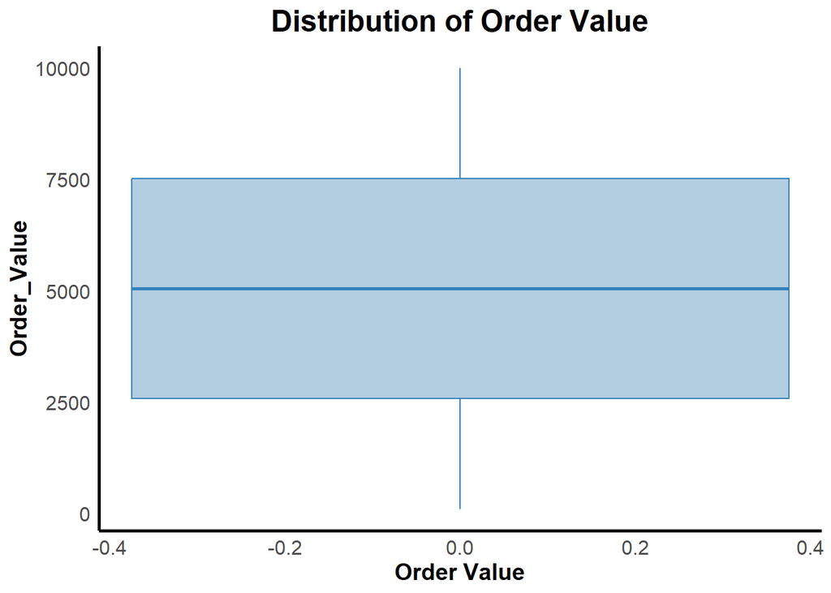

```r
#plot Boxplot to identiy any outlies in the dataframe
ggplot(data = smd, mapping = aes(y = Order_Value)) +
  geom_boxplot(fill = "#b3cde0", color = "#3182bd") +
  theme_minimal() +
  labs(x = "Order Value", title = "Distribution of Order Value") +
  theme(plot.title = element_text(size = 18, face = "bold", hjust = 0.5),
        axis.text = element_text(size = 12),
        axis.title = element_text(size = 14, face = "bold"),
        axis.line = element_line(linewidth = 1),
        panel.grid.major = element_blank(),
        panel.grid.minor = element_blank())
```

*2. Continued from #1, for any outliers present in the data. Specify the criteria used to identify them and provide a logical explanation for how you handled them.*

As shown in the boxplot, there are no points outside of the whiskers of the box plot and hence, it concludes that there are no outliers in the data.Alternatively, using the z-score method to identify outliers as it is always a good idea to use multiple methods to identify outliers and examine the data to determine if they are legitimate or errors in the data

```r
# Calculate the z-score for the Order Value column
z <- abs(scale(smd$Order_Value))

# Identify the index of any z-score greater than 3 (typical threshold for identifying outliers)
outliers <- which(z > 3)

# Print the outliers
smd[outliers,]
```

```
## # A tibble: 0 × 20
## # … with 20 variables: Order_Id <chr>, Company_Id <chr>, Company_Name <chr>,
## #   Date_ order_placed <chr>, DD_Order_Placed_Date <dbl>,
## #   MM _Order_Placed_Month <dbl>, YYYY_Order_Placed_Year <dbl>,
## #   Order_Value <dbl>, Converted <dbl>, Date <chr>, Meal_Id <chr>,
## #   Date_of_Meal <chr>, YYYY_Meal_Served_Year <dbl>,
## #   MM_Meal_Served_Month <dbl>, DD_Meal_Served_Date <dbl>, Participant <chr>,
## #   Meal_Price <dbl>, Type_of_Meal <chr>, Sales_Rep <chr>, Sales_Rep_Id <chr>
```

If there are no rows in the dataset with a z-score greater than 3, it means that there are no outliers in the dataset according to the z-score method.

*3. Describe the shape of the data.*

```r
#Check Summary Statistics of the dataframe
summary(smd$Order_Value)
```

```
##    Min. 1st Qu.  Median    Mean 3rd Qu.    Max.
##     100    2575    5046    5044    7517    9999
```

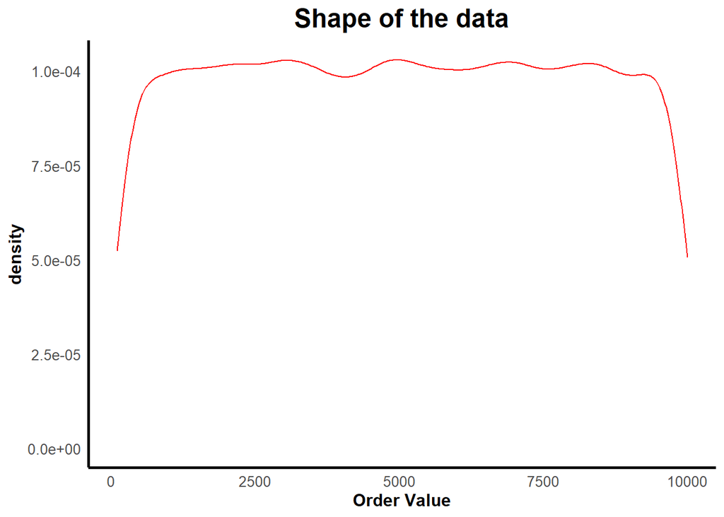

```r
#Plot density plot to identiy the shape of the data
ggplot(data = smd, mapping = aes(x = Order_Value))+
  geom_density(color = "Red")+
   labs(x = "Order Value", title = "Shape of the data") +
  theme_minimal()+
   theme(plot.title = element_text(size = 18, face = "bold", hjust = 0.5),
        legend.position = "right", legend.justification = "center",
        panel.grid.major = element_blank(),
        panel.grid.minor = element_blank(),
        axis.line = element_line(linewidth = 1),
        axis.text = element_text(size = 10),
        axis.title = element_text(size = 12, face = "bold"))
```

*4. Based on your answer to the previous question, decide if it is appropriate to apply a transformation to your data. If no, explain why not. If yes, name the transformation applied and visualize the transformed distribution.*

```r
#Log Transformation
summary(log10(smd$Order_Value +1))
```

```
##    Min. 1st Qu.  Median    Mean 3rd Qu.    Max.
##   2.004   3.411   3.703   3.585   3.876   4.000
```

```r
#square root transformation
summary(sqrt((smd$Order_Value)))
```

```
##    Min. 1st Qu.  Median    Mean 3rd Qu.    Max.
##   10.00   50.74   71.04   67.22   86.70  100.00
```

*5. Choose and calculate an appropriate measure of central tendency (Mean, Median, and Mode).*

Mean

```r
mean(smd$Order_Value)
```

```
## [1] 5044.088
```

Median

```r
median(smd$Order_Value)
```

```
## [1] 5046
```

Mode

```r
get_mode <- function(x) {
  unique_x <- unique(x)
  unique_x[which.max(tabulate(match(x, unique_x)))]
}

mode_value <- get_mode(smd$Order_Value)
print(mode_value)
```

```
## [1] 4858
```

*7. Choose and calculate a measure of spread (SD, MAD or IQR) that is appropriate for your chosen measure of central tendency. Explain why you chose this as your measure of spread.*

Since the shape of the data is uniform,the distribution is approximately symmetric, I would choose the interquartile range (IQR) as the measure of spread.The IQR is a robust measure of spread and is less sensitive to outliers compared to the standard deviation. Additionally, since the median is used as a measure of central tendency, the IQR is a natural choice as it is based on quartiles and is also robust to outliers.

IQR = 7517 - 2575 = 4942

So, the IQR for this dataset is 4942.

### B) For each categorical variable:

*1. Create an appropriate plot to visualize the distribution of counts for categorical variable “Type of Meal”.*

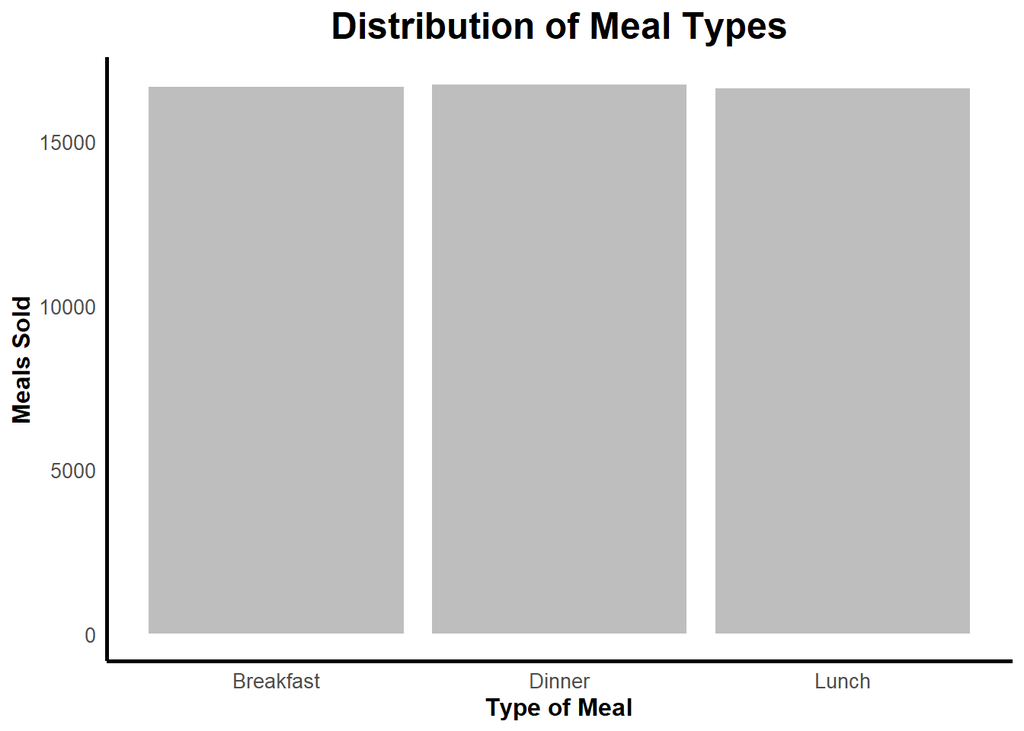

```r
# create a new dataframe with counts of each meal type
meal_counts <- smd %>%
  group_by(Type_of_Meal) %>%
  summarize(count = n())

# Plot to visualize the distribution of counts for categorical variable
ggplot(data = meal_counts, aes(x = Type_of_Meal, y = count)) +
  geom_bar(stat = "identity", fill = "Grey") +
  labs(x = "Type of Meal",y = "Meals Sold", title = "Distribution of Meal Types") +
  theme_minimal()+
   theme(plot.title = element_text(size = 18, face = "bold", hjust = 0.5),
        legend.position = "right", legend.justification = "center",
        panel.grid.major = element_blank(),
        panel.grid.minor = element_blank(),
        axis.line = element_line(linewidth = 1),
        axis.text = element_text(size = 10),
        axis.title = element_text(size = 12, face = "bold"))
```

*2. Create an appropriate plot to visualize the distribution of proportions for this variable.*

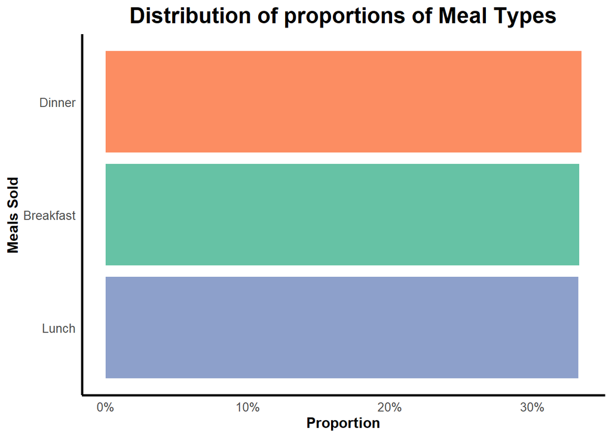

```r
# Summarize the data by meal type and count the number of occurrences
meal_counts <- smd %>%
  group_by(Type_of_Meal) %>%
  summarize(count = n()) %>%
  ungroup()

# Calculate the proportion of each meal type
meal_counts$prop <- meal_counts$count / sum(meal_counts$count)

# Plot to visualize the distribution of proportions for variables
ggplot(data = meal_counts, aes(x = prop, y = reorder(Type_of_Meal, prop), fill = Type_of_Meal)) +
  geom_col() +
  scale_x_continuous(labels = scales::percent_format()) +
  labs(x = "Proportion",y = "Meals Sold", title = "Distribution of proportions of Meal Types") +
  theme_minimal()+
   theme(plot.title = element_text(size = 18, face = "bold", hjust = 0.5),
        panel.grid.major = element_blank(),
        panel.grid.minor = element_blank(),
        axis.line = element_line(linewidth = 1),
        axis.text = element_text(size = 10),
        axis.title = element_text(size = 12, face = "bold"))+
   guides(fill = "none")+
  scale_fill_brewer(palette = "Set2")
```

*3. Discuss any unusual observations for this variable?*

```r
# Calculate the proportion of each meal type
meal_counts <- data.frame(table(smd$Type_of_Meal))
meal_counts$prop <- meal_counts$Freq / sum(meal_counts$Freq)
meal_counts
```

```
##        Var1  Freq      prop
## 1 Breakfast 16663 0.3331467
## 2    Dinner 16732 0.3345263
## 3     Lunch 16622 0.3323270
```

From the distribution plot and summary of the proportions of the “Type_of_Meal” variable, we can see that the counts are relatively balanced among the three categories: breakfast, lunch, and dinner. Each category has approximately one-third of the total counts, evenly distributed among the three meal types. Therefore, there are no unusual observations for this variable.

There are no particularly unusual observations for this variable based on this summary.

*4. Discuss if there are too few/too many unique values?*

```r
unique(smd$Type_of_Meal)
```

```
## [1] "Breakfast" "Dinner"    "Lunch"
```

```r
length(unique(smd$Type_of_Meal))
```

```
## [1] 3
```

The number of unique values for the categorical variable “Type_of_Meal” in the given dataset is appropriate, as it represents different categories of meals that can be ordered (Breakfast, Lunch, and Dinner), which is sufficient for analysis purposes. Having too few unique values could limit the analysis and insights that can be drawn from the data, while having too many unique values could make it difficult to analyze and visualize the data effectively.

Therefore, the current number of unique values is reasonable for the given dataset.

## **Bivariate Analysis**

### PAIR I : Both variables are Numeric

*1. Create an appropriate plot to visualize the relationship between two numeric variables “Meal served each year” and “Order value”*

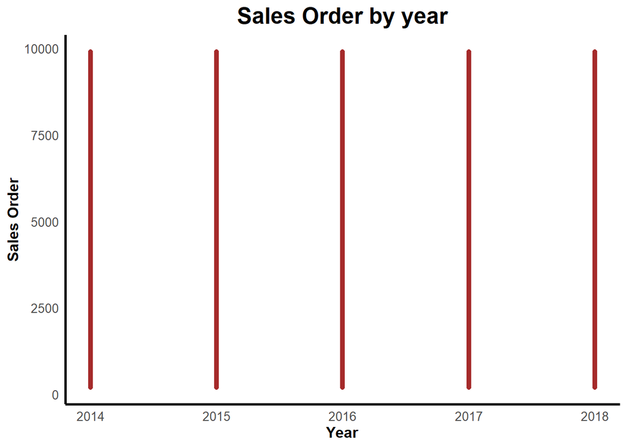

```r
# Remove outliers in Order_Value and YYYY_Meal_Served_Year
smd_cleaned <- smd %>%
  filter(YYYY_Meal_Served_Year != 2013 & YYYY_Meal_Served_Year != 2019) %>%
  mutate(Order_Value = ifelse(Order_Value < quantile(Order_Value, 0.01) | Order_Value > quantile(Order_Value, 0.99), NA, Order_Value))

# Plot to visualize the relationship between two numeric variables
ggplot(smd_cleaned, aes(x = YYYY_Meal_Served_Year, y = Order_Value)) +
  geom_point(color = "Brown") +
  labs(x = "Year", y = "Sales Order", title = "Sales Order by year") +
  theme_minimal()+
   theme(plot.title = element_text(size = 18, face = "bold", hjust = 0.5),
        legend.position = "right", legend.justification = "center",
        panel.grid.major = element_blank(),
        panel.grid.minor = element_blank(),
        axis.line = element_line(linewidth = 1),
        axis.text = element_text(size = 10),
        axis.title = element_text(size = 12, face = "bold"))
```

*2. Describe the form, direction, and strength of the observed relationship.*

To calculate the strength of the relationship between “YYYY_Meal_Served_Year” and “Order_Value”, we can use a correlation coefficient. In this case, since both variables are numeric, we can use Pearson’s correlation coefficient. The value of the correlation coefficient ranges between -1 and 1, where -1 indicates a perfectly negative correlation, 0 indicates no correlation, and 1 indicates a perfectly positive correlation.

We can calculate the correlation coefficient between the two variables using the cor() function in R:

```r
cor(smd$YYYY_Meal_Served_Year, smd$Order_Value)
```

```
## [1] 0.006473214
```

*3. Explain what this relationship means in the context of the data.*

The relationship between “YYYY_Meal_Served_Year” and “Order_Value” suggests that there is no significant variation in the average order value across different years. This means that the order value has remained relatively stable over the years, without showing any consistent trend of increase or decrease. It is possible that the prices of the meals have remained unchanged or the changes have been minimal, leading to a stable trend in order values over the years. Alternatively, there could be other factors that affect order values, such as the number of participants or the type of meal, which have remained consistent over the years, resulting in a stable trend.

*4. Describe the variability that you observe in the plot and how that corresponds to the strength you calculated.*

We can conclude that while there is a small positive relationship between the two variables, it is not very strong, and there is a lot of variability in the data that cannot be explained by the year in which the meal was served.

### PAIR II : One variable is Categorical and the other is Numeric

*1. Create an appropriate plot to visualize the relationship between categorical “Type of Meals” and numeric variable “Meal Served each year”*

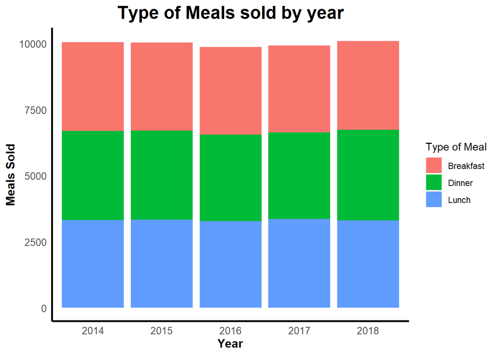

```r
# Remove outliers in Type _of_Meal and YYYY_Meal_Served_Year
smd_cleaned <- smd %>%
  filter(YYYY_Meal_Served_Year != 2013 & YYYY_Meal_Served_Year != 2019) %>%
  group_by(Type_of_Meal, YYYY_Meal_Served_Year) %>%
  mutate(Order_Value = ifelse(Order_Value < quantile(Order_Value, 0.05) | Order_Value > quantile(Order_Value, 0.95), NA, Order_Value))

# Plot to visualize the relationship between categorical and numeric variables
ggplot(smd_cleaned, aes(x = factor(YYYY_Meal_Served_Year), fill = Type_of_Meal)) +
  geom_bar(position = "stack") +
  labs(x = "Year", y = "Meals Sold", fill = "Type of Meal", title = "Type of Meals sold by year") +
  theme_minimal()+
   theme(plot.title = element_text(size = 18, face = "bold", hjust = 0.5),
        legend.position = "right", legend.justification = "center",
        panel.grid.major = element_blank(),
        panel.grid.minor = element_blank(),
        axis.line = element_line(linewidth = 1),
        axis.text = element_text(size = 10),
        axis.title = element_text(size = 12, face = "bold"))
```

*2. Describe the form, direction, and strength of the observed relationship.*

The form of the observed relationship between “Type_of_Meal” and “YYYY_Meal_Served_Year” is a stacked bar chart, which shows the proportion of each type of meal served in each year.

Since “Type_of_Meal” is a categorical variable and “YYYY_Meal_Served_Year” is a numeric variable, we cannot calculate correlation coefficient as we did for two numeric variables.However, based on the stacked bar plot, the relationship between “Type_of_Meal” and “YYYY_Meal_Served_Year” appears to be weak and potentially non-existent. The stacked bar plot shows that the distribution of meal types is relatively consistent across years, with no clear pattern or trend.

*3. Explain what this relationship means in the context of the data.*

The relationship between “Type_of_Meal” and “YYYY_Meal_Served_Year” indicates how the distribution of meals served in different years varies by the type of meal. The stacked bar chart shows the proportion of each type of meal served for each year.

The chart also shows that there is a consistent trend in the proportion of lunch and dinner meals served, indicating that the restaurant has maintained its popularity for these meals over the years. This relationship helps us to understand how the restaurant’s menu and offerings have changed over time and can provide insights into the dining trends and customer preferences and trends.

*4. Describe the variability that you observe in the plot and how that corresponds to the strength you calculated in #2 above.*

The stacked bar chart also shows that there is no clear pattern or trend in the data over time, with some types of meals showing an increase in the number of meals served in some years and a decrease in others. Overall, while there appears to be some association between the two variables, the variability in the data suggests that other factors beyond year and meal type may be influencing the number of meals served.

# **2. Analysis by Aesha Rathod**

## Univariate Analysis

### Numeric variable

#### **Dataset:** Supermarket Ordering, Invoicing, and Sales Analysis **Numerical variable:** Meal Price **Categorical variable:** 1. OrderValue vs. MealPrice, 2. OrderValue vs. CompanyName

**Create a boxplot**

```r
library(readxl)
Merged <- read_excel("C:/Users/MY PC/Desktop/DAB_Project2/Datasets/Merged.xlsx")
```

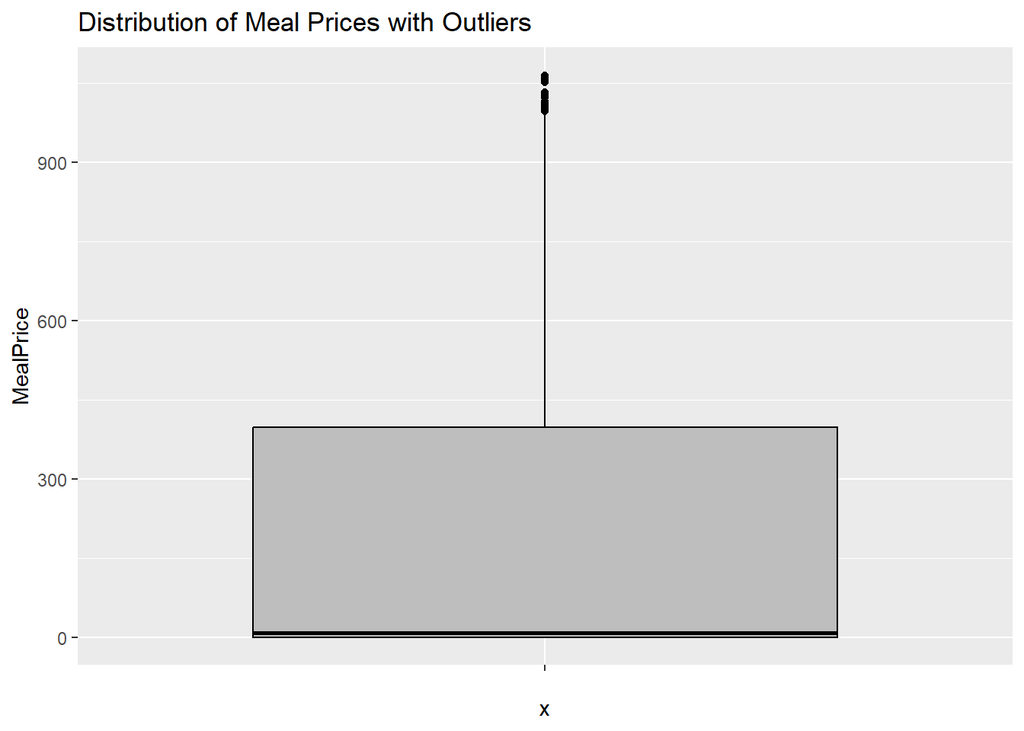

```r
library(ggplot2)
library(dplyr)
library(gridExtra)
#Replaced NA with 0 for further analysis, dont want to delete the rows because of the limited observations
Merged$MealPrice <- ifelse(is.na(Merged$MealPrice), 0, Merged$MealPrice)
ggplot(data = Merged, aes(x = "", y = MealPrice)) +
  geom_boxplot(fill = "grey", color = "black") +
  ggtitle("Distribution of Meal Prices with Outliers")
```

**1. Clean the data for any outlier/extreme values using the filtering technique and create an appropriate plot to visualize the distribution of this variable. (4 marks)**

```r
q1 <- quantile(Merged$MealPrice, 0.25)
q3 <- quantile(Merged$MealPrice, 0.75)
iqr_x <- IQR(Merged$MealPrice)

data1 <- Merged[(Merged$MealPrice >= q1 - 1.5*iqr_x) & (Merged$MealPrice <= q3 + 1.5*iqr_x), ]
```

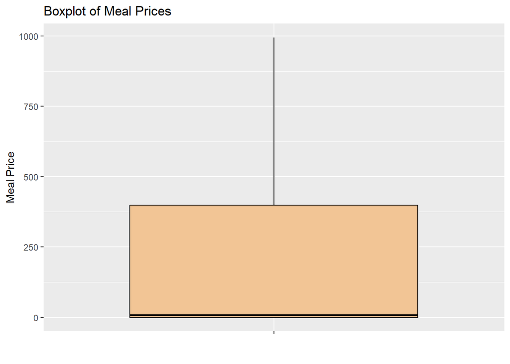

```r
ggplot(data1, aes(x = "", y = MealPrice)) +
  geom_boxplot(fill = "#f2c595", color = "black") +
  labs(x = "", y = "Meal Price", title = "Boxplot of Meal Prices")
```

**2. Continued from #1, for any outliers present in the data. Specify the criteria used to identify them and provide a logical explanation for how you handled them. (4 marks)**

I applied the interquartile range (IQR) method to find outliers in the data. Any data point outside the range (Q1 - 1.5IQR, Q3 + 1.5IQR) was regarded as an outlier. I calculated the IQR by subtracting the 25th percentile (Q1) from the 75th percentile (Q3).I made the decision to remove the outliers from the dataset after finding them. This is because outliers can skew analysis and reduce the precision of statistical models. Removing outliers can increase the analysis’s accuracy and generate more insightful results.

**4. Based on your answer to the previous question, decide if it is appropriate to apply a transformation to your data. If no, explain why not. If yes, name the transformation applied and visualize the transformed distribution. (This video and this video may help.) (4 marks)**

The data appears to be skewed or has extreme outliers, we can consider applying a transformation to normalize the data.

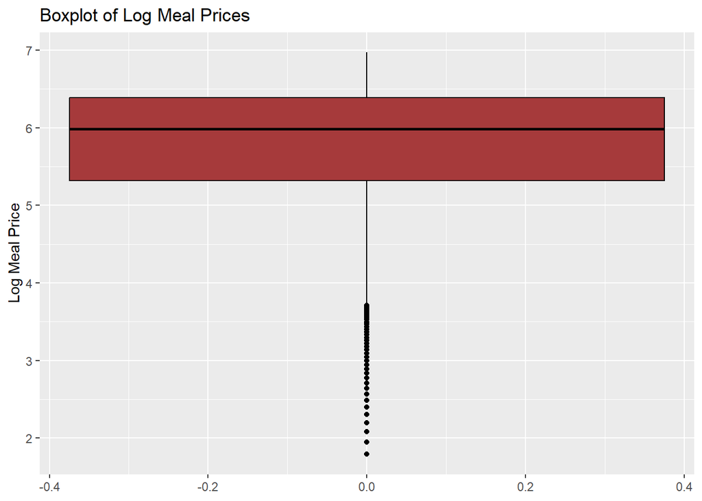

```r
# Apply natural logarithm transformation
Merged$log_MealPrice <- log(Merged$MealPrice)

# Plot transformed distribution using a Boxplot
ggplot(Merged, aes(y = log_MealPrice)) +
  geom_boxplot(fill = "#a63a3b", color = "black") +
  labs(y = "Log Meal Price", title = "Boxplot of Log Meal Prices")
```

**4 Watched video and tried to apply the same fucntionality to the data column i am visualizing.FOR checking purpose only**

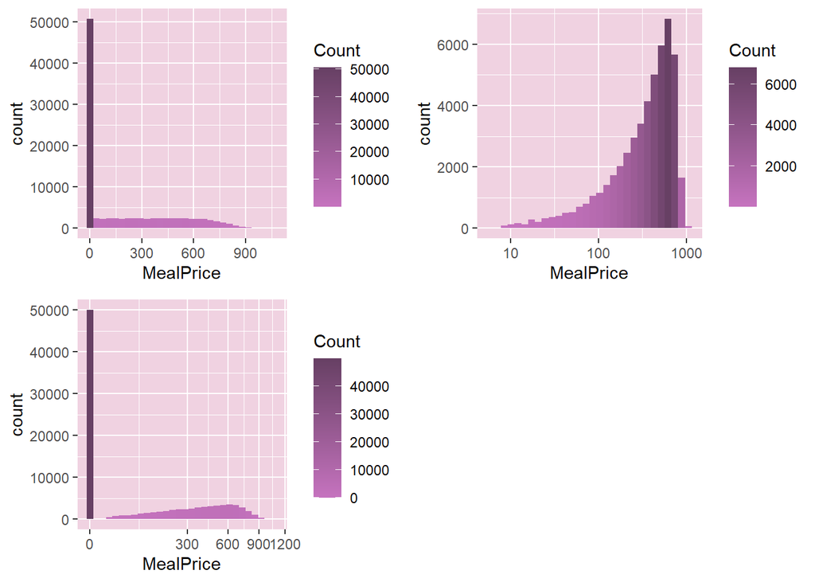

```r
library(gridExtra)
a1 <- ggplot( data = Merged, mapping = aes(x = MealPrice, fill = ..count..)) +
  geom_histogram() +
  scale_fill_gradient(low = "#c673bf", high = "#674064") +
  labs(fill = "Count")+
  theme(panel.background = element_rect(fill = "#f0d2e1"))
a2<- a1+scale_x_log10()
a3<-a1+scale_x_sqrt()
grid.arrange(a1,a2,a3,ncol=2,nrow=2)
```

**5. Choose and calculate an appropriate measure of central tendency (Mean, Median, and Mode). (3 marks)**

We inferred from the previous analysis that the data are positively skewed. Since it is less sensitive to extreme values than the mean in these situations, the median is typically a better indicator of central tendency.As a result, we will calculate central tendency using the median.

```r
median(Merged$MealPrice)
```

```
## [1] 8
```

**6. Explain why you chose this as your measure of central tendency. Provide supporting evidence for your choice. (4 marks)**  
The data appears to be right-skewed according to the boxplot, so the median might be a better indicator of central tendency than the mean. The median is more robust in the presence of outliers because it is less impacted by extreme values.

The resulting boxplot will show the median, quartiles, and any outliers present in the data.

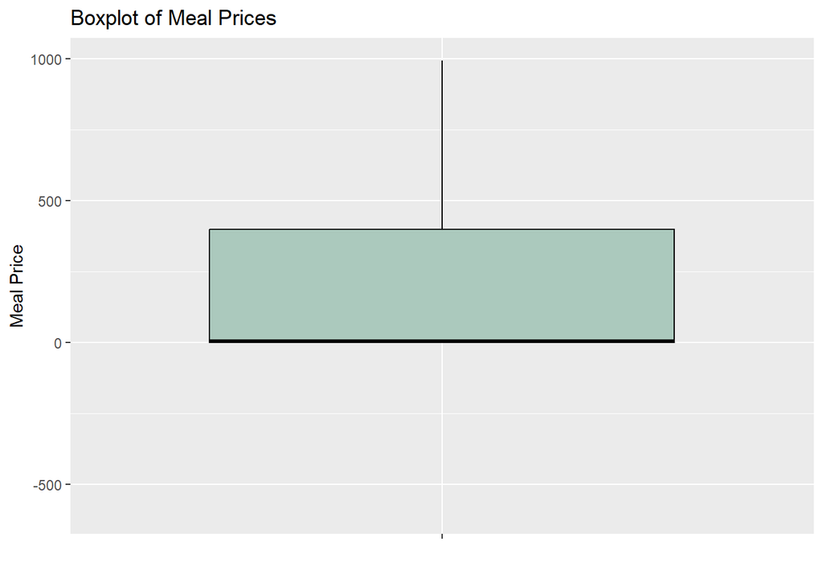

```r
# Calculate IQR
q1 <- quantile(Merged$MealPrice, 0.25)
q3 <- quantile(Merged$MealPrice, 0.75)
iqr_x <- q3 - q1

# Create boxplot
ggplot(Merged, aes(x="", y=MealPrice)) +
  geom_boxplot(fill = "#abc9bd", color = "black") +
  labs(x = "", y = "Meal Price", title = "Boxplot of Meal Prices") +
  scale_y_continuous(limits = c(q1 - 1.5*iqr_x, q3 + 1.5*iqr_x))
```

### Categorical variable:

**For each categorical variable:**  
**1. Create an appropriate plot to visualize the distribution of counts for this variable. (4 marks)**  
The Meal price variable is continuous variable not a categorical variable so by binning the meal prices into price ranges and then creating a count plot based on the price ranges.

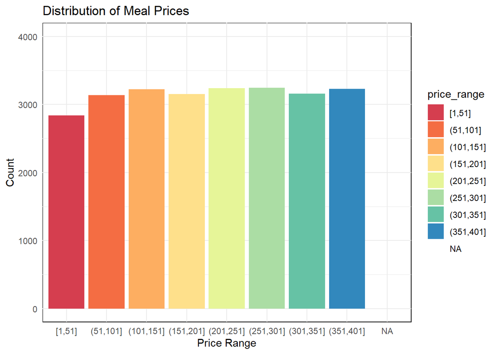

```r
# Create bins for meal prices
bins <- seq(1, 450, by = 50)

# Bin the meal prices
Merged$price_range <- cut(Merged$MealPrice, bins, include.lowest = TRUE)

# Create count plot
ggplot(Merged, aes(x = price_range, fill = price_range)) +
  geom_bar() +
  scale_fill_brewer(palette = "Spectral") +
  theme_minimal() +
  scale_y_continuous(limits = c(0, 4000))+
  labs(x = "Price Range", y = "Count", title = "Distribution of Meal Prices")+
  theme(panel.background = element_rect(fill = "white"))
```

**2. Create an appropriate plot to visualize the distribution of proportions for this variable. (4 marks)**  
Below i took the copy of the Same dataset and changed the name of the dataset Merged to MergedOrder2 Dataset for this particular datset because it effecting the whole dataset and further analysis is left.

We can use the prop.table() function to calculate the proportions and then create a bar plot to visualize the distribution of proportions for the meal price variable in the combined dataset.

```r
library(readxl)
MergedOrders2 <- read_excel("Datasets/MergedOrders2.xlsx")
```

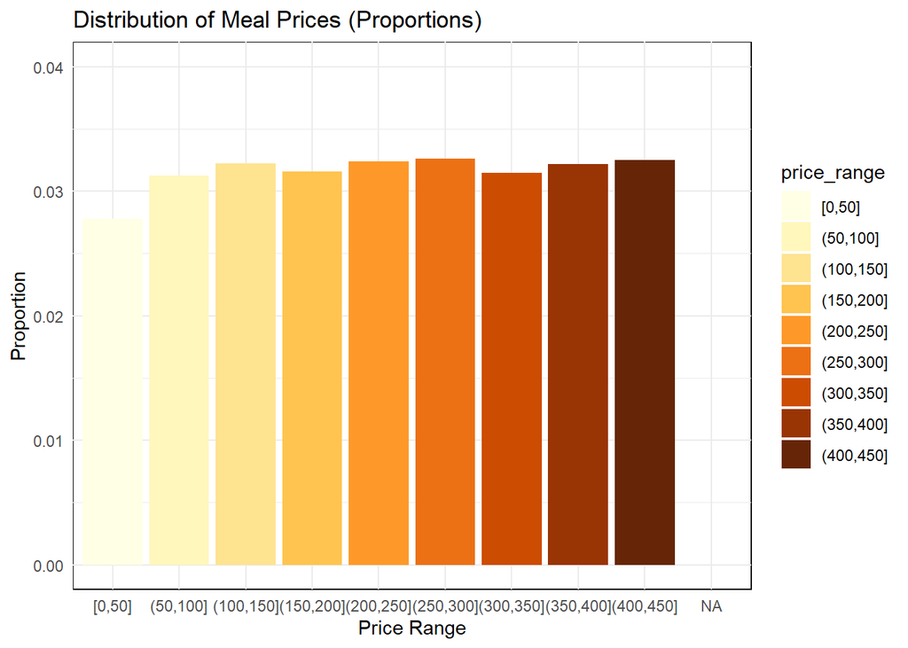

```r
library(dplyr)
# Create bins for meal prices
bins <- seq(0, 450, by = 50)

# Bin the meal prices
MergedOrders2$MealPrice <- as.numeric(as.character(MergedOrders2$MealPrice))
bins <- seq(0, 450, by = 50)
MergedOrders2$price_range <- cut(MergedOrders2$MealPrice, bins, include.lowest = TRUE)


# Group by price range and calculate proportions
merged_prop <- MergedOrders2 %>%
  group_by(price_range) %>%
  summarise(count = n()) %>%
  mutate(Proportion = count / sum(count))

# Create bar plot
ggplot(merged_prop, aes(x = price_range, y = Proportion, fill = price_range)) +
   scale_y_continuous(limits = c(0, 0.04)) +
  geom_col() +
  scale_fill_brewer(palette = "YlOrBr") +
  theme_minimal() +
  labs(x = "Price Range", y = "Proportion", title = "Distribution of Meal Prices (Proportions)")+
  theme(panel.background = element_rect(fill = "white"))
```

**4. Discuss if there are too few/too many unique values? (2 marks)**  
While having a large number of unique values can give the data a detailed view, it can also make the data challenging to visualize and analyze.The number of unique values was decreased in this instance by grouping the meal prices into bins, which also made it simpler to see how the meal prices were distributed.All in all, the number of unique values for the MealPrice variable is not too few or too many for the purposes of this analysis.

## Bivariate Analysis

### For each pair of variables

**1. Create an appropriate plot to visualize the relationship between the two variables. (4 marks)**  
As limited number of columns in the dataset we can perform bivariate analysis on the following pairs of variables: 1. OrderValue vs. MealPrice - Relationship between Order Value and Meal Price 2. OrderValue vs. CompanyName - Distribution of Order Value by Company Name

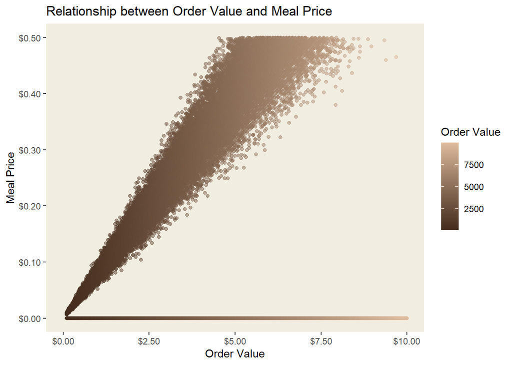

```r
ggplot(Merged, aes(x = OrderValue, y = MealPrice, color = OrderValue)) +
  geom_point(alpha = 0.5) +
  scale_x_continuous(labels = scales::dollar_format(scale = 0.001), limits = c(0, 10000)) +
  scale_y_continuous(labels = scales::dollar_format(scale = 0.001), limits = c(0, 500)) +
     scale_color_gradient(low = "#432c1d", high = "#ddbb9d") +
  labs(x = "Order Value", y = "Meal Price",color = "Order Value", title = "Relationship between Order Value and Meal Price")+
  theme(panel.background = element_rect(fill = "#f2ede1"),
        panel.grid.major = element_blank(),
        panel.grid.minor = element_blank())
```

[figure not shown]

```r
ggplot(Merged, aes(x = CompanyName, y = OrderValue, color = OrderValue)) +
  geom_point() +
  coord_flip() +
  scale_y_continuous(labels = scales::dollar_format(scale = 0.010), limits = c(0, 2500)) +
  labs(x = "Company Name", y = "Order Value", title = "Distribution of Order Value by Company Name")
```

**2. Describe the form, direction, and strength of the observed relationship. 4 marks)**

1. OrderValue vs. MealPrice We see a strong correlation between OrderValue and MealPrice in the scatter plot of the two variables. The MealPrice rises as the OrderValue does. The points on the plot form a fairly straight line from the lower left to the upper right, suggesting that the relationship is linear.
2. OrderValue vs. CompanyName OrderValue and CompanyName’s scatter plot reveals that there is no obvious correlation between the two variables. There is no clear pattern or trend among the points, which are dispersed throughout the story. This shows that OrderValue and CompanyName do not have a strong or significant relationship.

**3. Explain what this relationship means in the context of the data. (4 marks)**

1. OrderValue vs. MealPrice This connection offers information about customers’ spending habits. Businesses can use this data to optimize their menu offerings and pricing strategy in order to boost sales. For instance, they can determine which menu items are popular with customers who place larger orders and change their selections accordingly. To entice customers to spend more while maintaining a fair meal price, they can also introduce bundle offers.
2. OrderValue vs. CompanyName There is no particular pattern in the relationship, and the variation is not consistent. This suggests that the company of choice does not significantly affect the order value.Because of this, the relationship between OrderValue and CompanyName in the context of the data suggests that the choice of company has little to no impact on the order value.

**4. Describe the variability that you observe in the plot and how that corresponds to the strength you calculated in #2 above. (3 marks)**  
This variation is probably caused by things like different meal types and different order sizes. Despite the variation, the correlation’s strength suggests that OrderValue and MealPrice have a distinct and consistent relationship, with the meal price generally rising along with order value.

# **3. Analysis by Gurjinderpal Singh**

```r
library(ggplot2)
library(tidyverse)
library(dplyr)
```

## Univariate Analysis:

### Numeric variable:

#### **1. Clean the data for any outlier/extreme values using the filtering technique and create an appropriate plot to visualize the distribution of this variable.**

```r
library(readxl)
Invoices <- read_excel("C:/Users/MY PC/Desktop/DAB_Project2/Datasets/Invoices.xlsx")
```

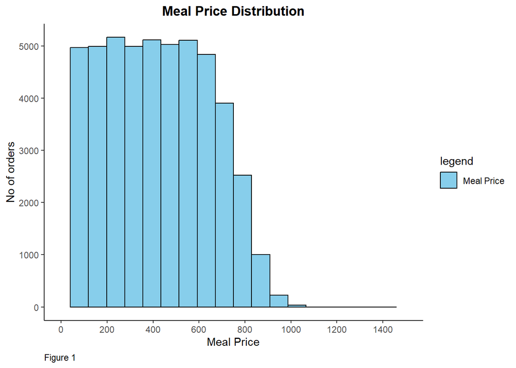

```r
ggplot(Invoices,aes(x=MealPrice,fill = "Mealprice"))+
  geom_histogram(color="black",bins = 20)+
  scale_x_continuous(breaks = seq(0, 1500, by = 200), limits = c(0, 1500)) +
  labs(x="Meal Price",
       y="No of orders" ,
       title = "Meal Price Distribution",
       caption = "Figure 1")+
  theme_classic()+
  theme(plot.title = element_text(hjust=0.5,face = "bold"))+
  theme(plot.caption = element_text(hjust = 0))+
  scale_fill_manual(name="legend",values=c("skyblue"), labels=c("Meal Price"))
```

**Filtering the Outliers and then plotting the data.**

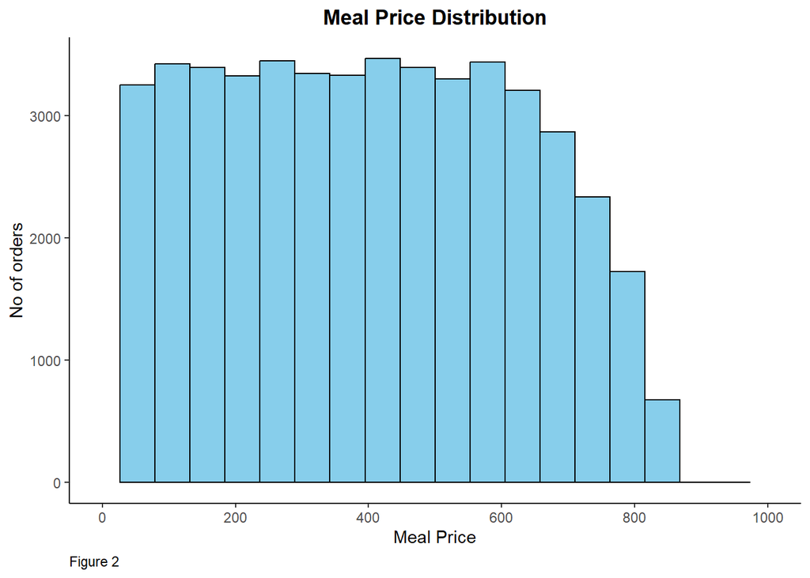

```r
Invoices_filtered <- Invoices %>%
  filter(MealPrice<850)

ggplot(Invoices_filtered,aes(x=MealPrice))+
  geom_histogram(fill = "skyblue",color="black",bins = 20)+
   labs(x="Meal Price",
       y="No of orders" ,
       title = "Meal Price Distribution",
       caption = "Figure 2")+
  theme_classic()+
  theme(plot.title = element_text(hjust=0.5,face = "bold"))+
  theme(plot.caption = element_text(hjust = 0))+
  scale_x_continuous(breaks = seq(0, 1000, by = 200), limits = c(0, 1000))
```

Plot 1

#### **2.Continued from #1, for any outliers present in the data. Specify the criteria used to identify them and provide a logical explanation for how you handled them.**

We plotted a histogram to get the distribution of meal price in Figure 1, clearly became visible that no of order with mealprice > 850 are significantly less as compared to our distribution.

To eliminate outliers , used the filter function of dplyr package and filtered the meal price <850.

#### **3.Describe the shape of the data.**

The data is of uniform distribution with no apparant peaks or clustering.

#### **4.Based on your answer to the previous question, decide if it is appropriate to apply a transformation to your data. If no, explain why not. If yes, name the transformation applied and visualize the transformed distribution.**

Transformations are typically not required on a uniform distribution of data, as it is already evenly distributed across the range of values. A uniform distribution has a constant probability density function (PDF) across the range of values, and any transformation applied to the data would not change this property.

#### **5.Choose and calculate an appropriate measure of central tendency (Mean, Median, and Mode).**

```r
mean_price <- mean(Invoices$MealPrice)
mean_price
```

```
## [1] 403.2567
```

#### **6.Explain why you chose this as your measure of central tendency. Provide supporting evidence for your choice.**

We calculate mean as the measure of central tendency as it gives the average price of meal order received by the store. Below plot shows the mean value of the meal price distribution with dotted red line.

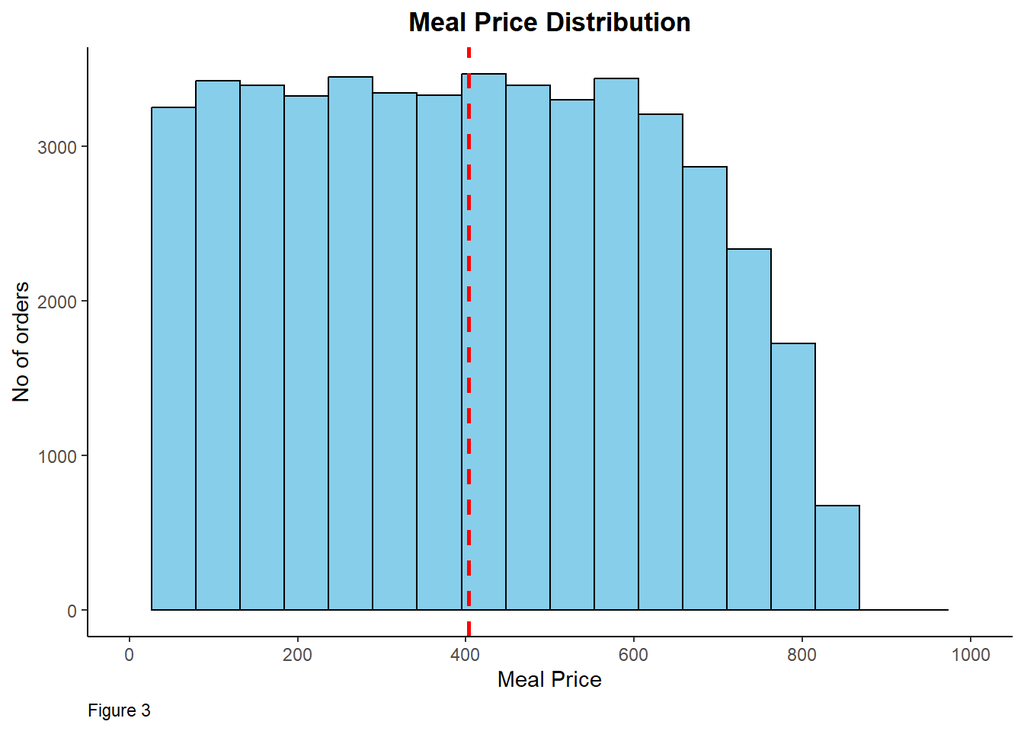

```r
ggplot(Invoices_filtered, aes(x=MealPrice))+
  geom_histogram(fill = "skyblue",color="black",bins = 20)+
  theme_classic()+
  geom_vline(aes(xintercept = mean_price), color="red", linetype="dashed", size=1)+
  labs(x="Meal Price",
       y="No of orders" ,
       title = "Meal Price Distribution",
       caption = "Figure 3")+
  theme_classic()+
  theme(plot.title = element_text(hjust=0.5,face = "bold"))+
  theme(plot.caption = element_text(hjust = 0))+
  scale_x_continuous(breaks = seq(0, 1000, by = 200), limits = c(0, 1000))
```

#### 7.Choose and calculate a measure of spread (SD, MAD or IQR) that is appropriate for your chosen measure of central tendency. Explain why you chose this as your measure of spread.

We calculate the IQR for the MealPrice distribution as it is uniformly distributed.

The IQR measures the spread of the middle 50% of the data and is less sensitive to outliers than the standard deviation.

```r
q1 <- quantile(Invoices$MealPrice, 0.25)
q3 <- quantile(Invoices$MealPrice, 0.75)
iqr_price <- q3 - q1
iqr_price
```

```
## 75%
## 389
```

### Categorical variable

```r
library(readxl)
OrderLeads <- read_excel("C:/Users/MY PC/Desktop/DAB_Project2/Datasets/OrderLeads.xlsx")
```

Created new column category in OrderLeads dataFrame.

```r
OrderLeads<- OrderLeads %>%
  mutate(category=cut(OrderValue,breaks = c(-Inf, 1000,6000, Inf), labels=c("low","middle","high")))
```

#### 1.Create an appropriate plot to visualize the distribution of counts for this variable. (4 marks)

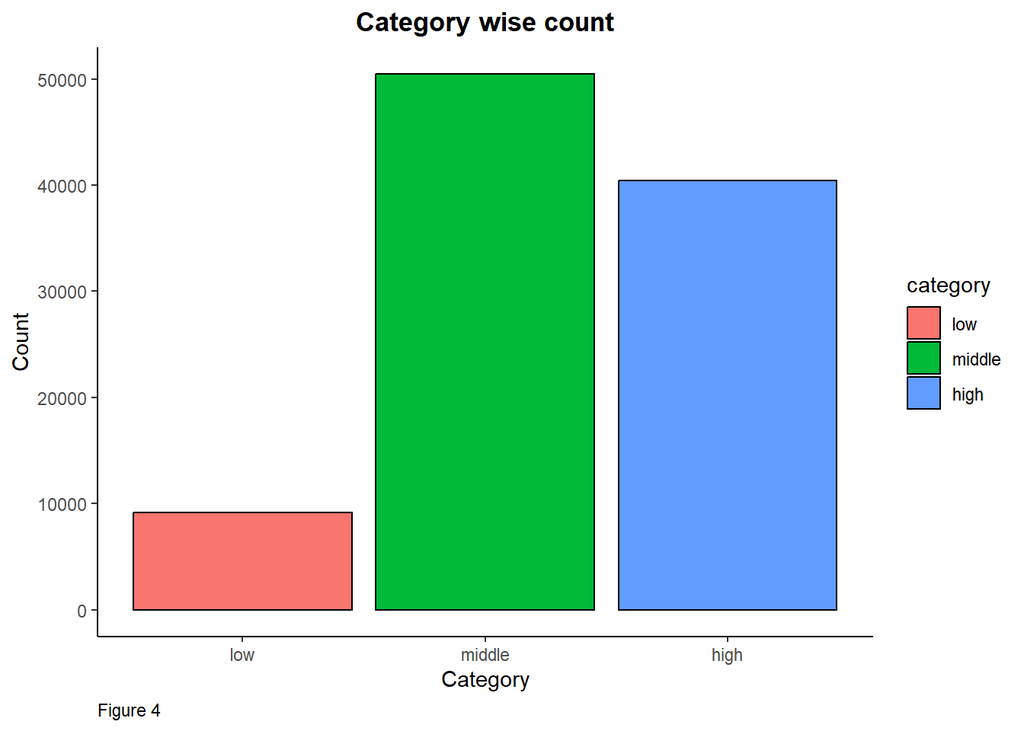

```r
ggplot(OrderLeads,aes(x=category))+
  geom_bar(aes(fill = category),color="black")+
  theme_classic()+
  labs(x="Category",
       y="Count" ,
       title = "Category wise count",
       caption = "Figure 4")+
  theme(plot.title = element_text(hjust=0.5,face = "bold"))+
  theme(plot.caption = element_text(hjust = 0))
```

#### 2.Create an appropriate plot to visualize the distribution of proportions for this variable. (4 marks)

```
## Defaulting to continuous.
```

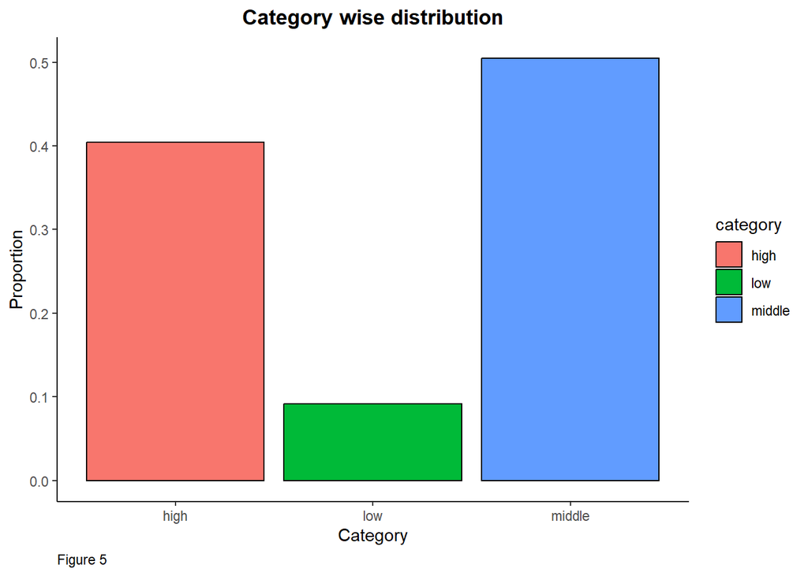

```r
# Calculate the proportion of each category in the dataset
category_prop <- prop.table(table(OrderLeads$category))
category = names(category_prop)
category_proportions <- data.frame(category,category_prop)

# Create a bar chart of the proportions
ggplot(category_proportions,
       aes(x = category, y = category_prop, fill = category)) +
  geom_bar(stat = "identity", color = "black") +
  theme_classic()+
  labs(x="Category",
       y="Proportion" ,
       title = "Category wise distribution",
       caption = "Figure 5")+
  theme(plot.title = element_text(hjust=0.5,face = "bold"))+
  theme(plot.caption = element_text(hjust = 0))
```

#### 3.Discuss any unusual observations for this variable? (2 marks)

There are significantly less no of orders of low category as compared to Medium and High category orders.

```r
OrderLeads %>%
  group_by(category) %>%
  summarise(number = n())
```

```
## # A tibble: 3 × 2
##   category number
##   <fct>     <int>
## 1 low        9124
## 2 middle    50478
## 3 high      40398
```

## Bivariate Analysis

#### Create an appropriate plot to visualize the relationship between the two variables. (4 marks)

### Between Two Continous Variables:

```r
library(readxl)
MergedOrders <- read_excel("C:/Users/MY PC/Desktop/DAB_Project2/Datasets/MergedOrders.xlsx")
```

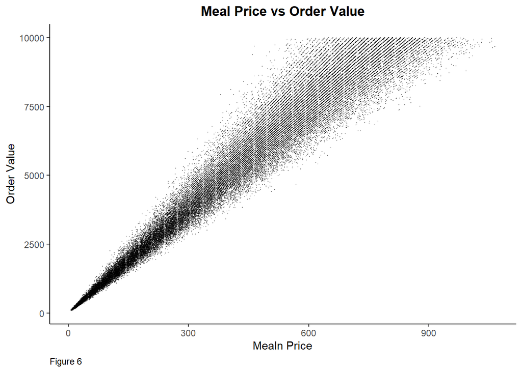

```r
ggplot(MergedOrders,aes(x=MealPrice,y=OrderValue))+
  geom_point(na.rm = TRUE,shape = ".", alpha = 0.5)+
  theme_classic()+
  labs(x="Mealn Price",
       y="Order Value" ,
       title = "Meal Price vs Order Value",
       caption = "Figure 6")+
  theme(plot.title = element_text(hjust=0.5,face = "bold"))+
  theme(plot.caption = element_text(hjust = 0))
```

### Between 1 Categorical And 1 Continous variable:

```r
Converted_No_Of_Orders <- OrderLeads %>%
  filter(Converted == "Converted") %>%
  group_by(CompanyName) %>%
  summarise(OrderValuesPerCompany = sum(OrderValue),
            NoOrders = n()) %>%
  arrange(desc(OrderValuesPerCompany)) %>%
  filter(OrderValuesPerCompany >57800)
```

[figure not shown]

```r
ggplot(Converted_No_Of_Orders,aes(x=OrderValuesPerCompany,y=CompanyName))+
  geom_point(aes(size=NoOrders,color=CompanyName))+
  theme_light()+
   labs(x="Total Order sales per Company",
       y="Company Name" ,
       title = "Order sales per Company",
       caption = "Figure 7")+
  theme(plot.title = element_text(hjust=0.5,face = "bold"))+
  theme(plot.caption = element_text(hjust = 0))
```

#### 2.Describe the form, direction, and strength of the observed relationship. (4 marks)

For Figure 6 :

1. Form: The form of the relationship between MealPrice and OrderValue appears to be somewhat linear.
2. Direction: The direction of the relationship between MealPrice and OrderValue is positive.
3. Strength: The strength of the relationship between MealPrice and OrderValue appears to be moderate.

#### 4.Describe the variability that you observe in the plot and how that corresponds to the strength you calculated in #2 above. (3 marks)

For Figure 6:

There is some spread of the data points around the trend line. However, the spread is not excessive, which indicates a moderate strength of the relationship between MealPrice and OrderValue.

# **4. References**

1. Datacamp learnings
2. Youtube videos
3. In-Class materials
4. Themes for R markdown: https://prettydoc.statr.me/

# **5. Academic Integrity**

We, **Aesha Rathod**, **Gurjinderpal Singh** and **Tehsin Shaikh**, hereby state that we have not communicated with or gained information in any way from any person or resource that would violate the College’s academic integrity policies, and that all work presented is our own. In addition, we also agree not to share our work in any way, before or after submission, that would violate the College’s academic integrity policies.